# Linear Regression Model: Crime Rate

Muhamad Iqbal Januadi P

1/9/2021

## Crime Rate

> There are significant research and finding about crime trends in different location and how socio-demographic factors can influence this trend. This project will explore how crime rate is significantly influenced by socio-demographic variables using linear regression model.

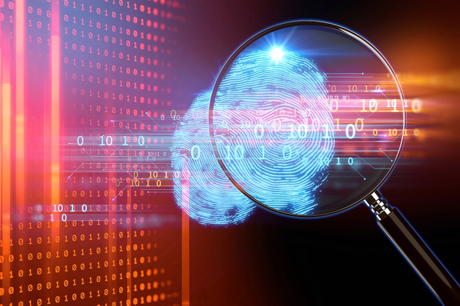

## 1. Do the data preparation steps for `crime` dataset

> Import `crime` dataset from data_input folder to R

```r
crime <- read.csv("data_input/crime.csv")
```

> Renaming the column names of “crime” data

```r
names(crime) <- c("X" ,"percent_m", "is_south", "mean_education", "police_exp60", "police_exp59", "labour_participation", "m_per1000f", "state_pop", "nonwhites_per1000", "unemploy_m24", "unemploy_m39", "gdp", "inequality", "prob_prison", "time_prison", "crime_rate")
```

> The dataset was collected in 1960 and a full description of the dataset wasn’t conveniently available. I use the description I gathered from the authors of the MASS package. After you rename the dataset, the variables are:
- `percent_m`: percentage of males aged 14-24
- `is_south`: whether it is in a Southern state. 1 for Yes, 0 for No.
- `mean_education`: mean years of schooling
- `police_exp60`: police expenditure in 1960
- `police_exp59`: police expenditure in 1959
- `labour_participation`: labour force participation rate
- `m_per1000f`: number of males per 1000 females
- `state_pop`: state population
- `nonwhites_per1000`: number of non-whites resident per 1000 people
- `unemploy_m24`: unemployment rate of urban males aged 14-24
- `unemploy_m39`: unemployment rate of urban males aged 35-39
- `gdp`: gross domestic product per head
- `inequality`: income inequality
- `prob_prison`: probability of imprisonment
- `time_prison`: avg time served in prisons
- `crime_rate`: crime rate in an unspecified category

> Check data structure and missing data from `crime` dataset

```r
library(tidyverse)
glimpse(crime)
```

```
## Rows: 47
## Columns: 17
## $ X                    <int> 1, 2, 3, 4, 5, 6, 7, 8, 9, 10, 11, 12, 13, 14,...
## $ percent_m            <int> 151, 143, 142, 136, 141, 121, 127, 131, 157, 1...
## $ is_south             <int> 1, 0, 1, 0, 0, 0, 1, 1, 1, 0, 0, 0, 0, 0, 1, 1...
## $ mean_education       <int> 91, 113, 89, 121, 121, 110, 111, 109, 90, 118,...
## $ police_exp60         <int> 58, 103, 45, 149, 109, 118, 82, 115, 65, 71, 1...
## $ police_exp59         <int> 56, 95, 44, 141, 101, 115, 79, 109, 62, 68, 11...
## $ labour_participation <int> 510, 583, 533, 577, 591, 547, 519, 542, 553, 6...
## $ m_per1000f           <int> 950, 1012, 969, 994, 985, 964, 982, 969, 955, ...
## $ state_pop            <int> 33, 13, 18, 157, 18, 25, 4, 50, 39, 7, 101, 47...
## $ nonwhites_per1000    <int> 301, 102, 219, 80, 30, 44, 139, 179, 286, 15, ...
## $ unemploy_m24         <int> 108, 96, 94, 102, 91, 84, 97, 79, 81, 100, 77,...
## $ unemploy_m39         <int> 41, 36, 33, 39, 20, 29, 38, 35, 28, 24, 35, 31...
## $ gdp                  <int> 394, 557, 318, 673, 578, 689, 620, 472, 421, 5...
## $ inequality           <int> 261, 194, 250, 167, 174, 126, 168, 206, 239, 1...
## $ prob_prison          <dbl> 0.084602, 0.029599, 0.083401, 0.015801, 0.0413...
## $ time_prison          <dbl> 26.2011, 25.2999, 24.3006, 29.9012, 21.2998, 2...
## $ crime_rate           <int> 791, 1635, 578, 1969, 1234, 682, 963, 1555, 85...
```

## 2. Do data cleansing steps for `crime` dataset

> - Check missing value (NA)
> - Delete unused variable in `crime` dataset
> - Adjust the data types of `crime` dataset
> - Make new variable to explore ‘mean_education’

```r
crime %>%
  is.na()%>%
  colSums()
```

```
##                    X            percent_m             is_south
##                    0                    0                    0
##       mean_education         police_exp60         police_exp59
##                    0                    0                    0
## labour_participation           m_per1000f            state_pop
##                    0                    0                    0
##    nonwhites_per1000         unemploy_m24         unemploy_m39
##                    0                    0                    0
##                  gdp           inequality          prob_prison
##                    0                    0                    0
##          time_prison           crime_rate
##                    0                    0
```

```r
crime <- crime %>%
  select(-X) %>%
  mutate(is_south = as.factor(is_south))

crime2 <- crime %>%
  mutate(quad_edu = mean_education ^2)

crime3 <- crime %>%
  mutate(log_edu = log10(mean_education))
```

## 3. Explore the variables

> We want to know how much the socio-demographic influence `crime_rate`. Before conducting regression analysis, do the EDA (Exploratory Data Analysis) steps to look at the data conditions (how the relation between socio-demographic variables and `crime_rate`).

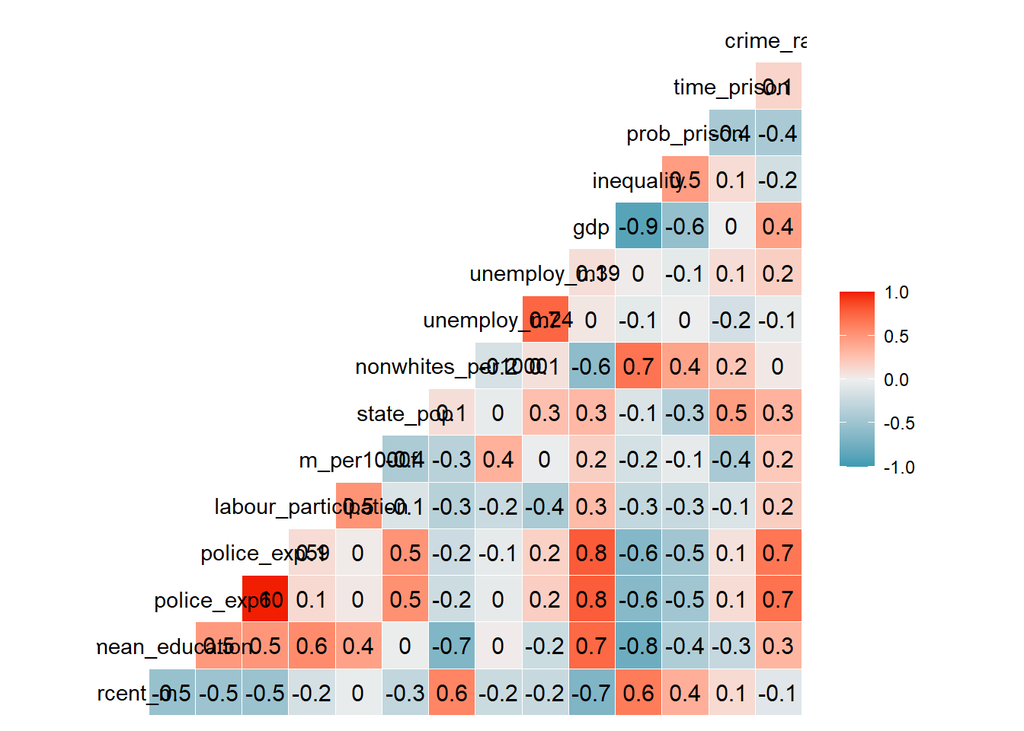

```r
library(GGally)
ggcorr(crime,label = T)
```

## Regression Model: Multiple Linear Regression

> Conducting the multiple linear regression operation to understand to relation between predictor variables (x axis) and the target variables (y axis). In this model, the predictor variables are the socio-demographic, while the target variable is the ‘crime_rate’. In a nutshell, this model will analyze how ‘crime_rate’ is influenced by other variables.

> y = crime_rate x = all predictor

## Exploring the regression model

> To find out the best model for crime_rate, we make several model that uses different predictor variables.
> 1. Model with all variable

```r
crime_model <- lm(formula = crime_rate ~ . , data = crime)
summary(crime_model)
```

```
##
## Call:
## lm(formula = crime_rate ~ ., data = crime)
##
## Residuals:
##     Min      1Q  Median      3Q     Max
## -395.74  -98.09   -6.69  112.99  512.67
##
## Coefficients:
##                        Estimate Std. Error t value Pr(>|t|)
## (Intercept)          -5984.2876  1628.3184  -3.675 0.000893 ***
## percent_m                8.7830     4.1714   2.106 0.043443 *
## is_south1               -3.8035   148.7551  -0.026 0.979765
## mean_education          18.8324     6.2088   3.033 0.004861 **
## police_exp60            19.2804    10.6110   1.817 0.078892 .
## police_exp59           -10.9422    11.7478  -0.931 0.358830
## labour_participation    -0.6638     1.4697  -0.452 0.654654
## m_per1000f               1.7407     2.0354   0.855 0.398995
## state_pop               -0.7330     1.2896  -0.568 0.573845
## nonwhites_per1000        0.4204     0.6481   0.649 0.521279
## unemploy_m24            -5.8271     4.2103  -1.384 0.176238
## unemploy_m39            16.7800     8.2336   2.038 0.050161 .
## gdp                      0.9617     1.0367   0.928 0.360754
## inequality               7.0672     2.2717   3.111 0.003983 **
## prob_prison          -4855.2658  2272.3746  -2.137 0.040627 *
## time_prison             -3.4790     7.1653  -0.486 0.630708
## ---
## Signif. codes:  0 '***' 0.001 '**' 0.01 '*' 0.05 '.' 0.1 ' ' 1
##
## Residual standard error: 209.1 on 31 degrees of freedom
## Multiple R-squared:  0.8031, Adjusted R-squared:  0.7078
## F-statistic: 8.429 on 15 and 31 DF,  p-value: 3.539e-07
```

> The intercept of this model is -5984.2876 Assuming the alpha value used for this model is 95% (0.05) Significant predictor variables to this model have probability value < 0.05 Significant variables to ‘crime_rate’: ‘percent_m’, ‘mean_education’, ‘inequality’, and ‘prob_prison’. Adjusted of R-squared is 70%. This means the predictor variables can only explain 70% of target variable (crime_rate). Other predictor variables that not included in this model explain to target variable as much as 30%. Interestingly, the mean_education has a positive relation towards the crime_rate. This means the crime_rate will be influenced if the mean_education is high. This doesn’t make sense. That’s why we propose different model (model 2) which take out the mean_education variables. The linear formula for this model:

$$Crime Rate = -5984.2876 + (8.7830) * percent_m + (18.832) * mean_education + (7.0672) * inequality + (-4855.2658) * prob_prison$$

> 2. Model using the above formula + take out the ‘mean_education’

```r
crime_model2 <- lm(formula = crime_rate ~ percent_m + is_south + police_exp60 + police_exp59 +
                     labour_participation + inequality + m_per1000f + state_pop + nonwhites_per1000 +
                     unemploy_m24 + unemploy_m39 + gdp + inequality + time_prison +  prob_prison, data = crime )

summary(crime_model2)
```

```
##
## Call:
## lm(formula = crime_rate ~ percent_m + is_south + police_exp60 +
##     police_exp59 + labour_participation + inequality + m_per1000f +
##     state_pop + nonwhites_per1000 + unemploy_m24 + unemploy_m39 +
##     gdp + inequality + time_prison + prob_prison, data = crime)
##
## Residuals:
##     Min      1Q  Median      3Q     Max
## -529.66  -85.86    0.75  119.11  412.44
##
## Coefficients:
##                        Estimate Std. Error t value Pr(>|t|)
## (Intercept)          -5280.5903  1806.4434  -2.923  0.00631 **
## percent_m                7.8910     4.6638   1.692  0.10037
## is_south1               23.0292   166.4337   0.138  0.89082
## police_exp60            14.0606    11.7356   1.198  0.23967
## police_exp59            -4.1522    12.9259  -0.321  0.75013
## labour_participation     0.7772     1.5589   0.499  0.62147
## inequality               5.6342     2.4905   2.262  0.03060 *
## m_per1000f               2.3100     2.2716   1.017  0.31681
## state_pop               -0.7892     1.4452  -0.546  0.58878
## nonwhites_per1000        0.1072     0.7171   0.149  0.88213
## unemploy_m24            -3.0254     4.6040  -0.657  0.51580
## unemploy_m39             9.1381     8.7858   1.040  0.30609
## gdp                      1.4249     1.1492   1.240  0.22405
## time_prison             -4.2312     8.0262  -0.527  0.60171
## prob_prison          -4616.2413  2545.4066  -1.814  0.07913 .
## ---
## Signif. codes:  0 '***' 0.001 '**' 0.01 '*' 0.05 '.' 0.1 ' ' 1
##
## Residual standard error: 234.3 on 32 degrees of freedom
## Multiple R-squared:  0.7446, Adjusted R-squared:  0.6329
## F-statistic: 6.665 on 14 and 32 DF,  p-value: 4.712e-06
```

> The intercept of this model is -5280.5903. Assuming the alpha value used for this model is 95% (0.05). Significant predictor variables to this model have probability value < 0.05. Significant variables to ‘crime_rate’: ‘inequality’. Adjusted of R-squared is 63%. This means the predictor variables can only explain 63% of target variable (crime_rate). Other predictor variables that not included in this model explain to target variable as much as 37%. This model has a lower Adjusted R-Squared value than the model 1.

> The linear formula for this model:

$$Crime Rate = -5280.5903 + (5.6342) * inequality$$
> Since the mean_education seems not look in the model, we explore this variable by make a quadratic and logarithmic value.

> 3. Model using quadratic ‘mean_education’

```r
crime_model3 <- lm(formula = crime_rate ~., data = crime2)
summary(crime_model3)
```

```
##
## Call:
## lm(formula = crime_rate ~ ., data = crime2)
##
## Residuals:
##     Min      1Q  Median      3Q     Max
## -386.46  -89.58  -23.79  108.10  505.08
##
## Coefficients:
##                        Estimate Std. Error t value Pr(>|t|)
## (Intercept)          -1.055e+04  4.533e+03  -2.327  0.02688 *
## percent_m             1.040e+01  4.421e+00   2.352  0.02545 *
## is_south1             1.071e+01  1.490e+02   0.072  0.94316
## mean_education        9.812e+01  7.375e+01   1.330  0.19341
## police_exp60          1.717e+01  1.076e+01   1.596  0.12099
## police_exp59         -8.116e+00  1.201e+01  -0.676  0.50426
## labour_participation -3.386e-01  1.496e+00  -0.226  0.82255
## m_per1000f            1.618e+00  2.033e+00   0.796  0.43237
## state_pop            -9.349e-01  1.300e+00  -0.719  0.47749
## nonwhites_per1000     3.998e-01  6.467e-01   0.618  0.54106
## unemploy_m24         -5.182e+00  4.242e+00  -1.222  0.23133
## unemploy_m39          1.762e+01  8.249e+00   2.136  0.04094 *
## gdp                   8.402e-01  1.040e+00   0.808  0.42552
## inequality            7.358e+00  2.282e+00   3.225  0.00304 **
## prob_prison          -4.914e+03  2.267e+03  -2.168  0.03826 *
## time_prison          -3.325e+00  7.148e+00  -0.465  0.64519
## quad_edu             -3.743e-01  3.469e-01  -1.079  0.28924
## ---
## Signif. codes:  0 '***' 0.001 '**' 0.01 '*' 0.05 '.' 0.1 ' ' 1
##
## Residual standard error: 208.5 on 30 degrees of freedom
## Multiple R-squared:  0.8104, Adjusted R-squared:  0.7093
## F-statistic: 8.016 on 16 and 30 DF,  p-value: 6.381e-07
```

> The intercept of this model is -1.055e+04. Assuming the alpha value used for this model is 95% (0.05). Significant predictor variables to this model have probability value < 0.05. Significant variables to ‘crime_rate’: ‘percent_m’, ‘unemploy_m39’, ‘inequality’, ‘prob_prison’. Adjusted of R-squared is 70%. This means the predictor variables can only explain 70% of target variable (crime_rate). Other predictor variables that not included in this model explain to target variable as much as 30%.

> The linear formula for this model:

$$Crime Rate = -1.055e+04 + (1.040e+01) * percent_m + (1.762e+01) * unemploy_m39 + (7.358e+00) * inequality + (-4.914e+03) prob_prison$$

> 4. Model using quadratic log ‘mean_education’

```r
crime_model6 <- lm(formula = crime_rate ~., data = crime3)
summary(crime_model6)
```

```
##
## Call:
## lm(formula = crime_rate ~ ., data = crime3)
##
## Residuals:
##     Min      1Q  Median      3Q     Max
## -385.48  -90.04  -21.82  107.51  505.17
##
## Coefficients:
##                        Estimate Std. Error t value Pr(>|t|)
## (Intercept)          -3.772e+04  2.788e+04  -1.353  0.18614
## percent_m             1.048e+01  4.411e+00   2.377  0.02405 *
## is_south1             1.232e+01  1.487e+02   0.083  0.93454
## mean_education       -6.268e+01  7.175e+01  -0.874  0.38926
## police_exp60          1.704e+01  1.074e+01   1.586  0.12326
## police_exp59         -7.948e+00  1.198e+01  -0.663  0.51220
## labour_participation -3.022e-01  1.497e+00  -0.202  0.84135
## m_per1000f            1.573e+00  2.031e+00   0.774  0.44474
## state_pop            -9.570e-01  1.298e+00  -0.737  0.46678
## nonwhites_per1000     3.974e-01  6.453e-01   0.616  0.54261
## unemploy_m24         -5.164e+00  4.230e+00  -1.221  0.23170
## unemploy_m39          1.779e+01  8.242e+00   2.159  0.03901 *
## gdp                   8.304e-01  1.038e+00   0.800  0.43000
## inequality            7.378e+00  2.277e+00   3.240  0.00292 **
## prob_prison          -4.925e+03  2.262e+03  -2.177  0.03748 *
## time_prison          -3.384e+00  7.131e+00  -0.474  0.63859
## log_edu               1.976e+04  1.733e+04   1.140  0.26316
## ---
## Signif. codes:  0 '***' 0.001 '**' 0.01 '*' 0.05 '.' 0.1 ' ' 1
##
## Residual standard error: 208.1 on 30 degrees of freedom
## Multiple R-squared:  0.8113, Adjusted R-squared:  0.7106
## F-statistic:  8.06 on 16 and 30 DF,  p-value: 6.016e-07
```

> The intercept of this model is -3.772e+04. Assuming the alpha value used for this model is 95% (0.05). Significant predictor variables to this model have probability value < 0.05. Significant variables to ‘crime_rate’: ‘percent_m’, ‘unemploy_m39’, ‘inequality’, ‘prob_prison’. Adjusted of R-squared is 71%. This means the predictor variables can only explain 70% of target variable (crime_rate). Other predictor variables that not included in this model explain to target variable as much as 29%.

> The linear formula for this model:

$$Crime Rate = -3.772e+04 + (1.048e+01) * percent_m + (1.779e+01) * unemploy_m39 + (7.378e+00) * inequality + (-4.925e+03) * prob_prison$$

> In order to get better model, we apply the stepwise multilinear regression to determine the best predictor variable in the model.
> 5. Exploring regression model using stepwise regression to know significant variables

```r
# model without predictor
model_none <- lm(crime_rate ~ 1, data = crime)
```

> 5.a Backward Stepwise

```r
backward <- step(object = crime_model, direction = "backward")
```

```
## Start:  AIC=514.65
## crime_rate ~ percent_m + is_south + mean_education + police_exp60 +
##     police_exp59 + labour_participation + m_per1000f + state_pop +
##     nonwhites_per1000 + unemploy_m24 + unemploy_m39 + gdp + inequality +
##     prob_prison + time_prison
##
##                        Df Sum of Sq     RSS    AIC
## - is_south              1        29 1354974 512.65
## - labour_participation  1      8917 1363862 512.96
## - time_prison           1     10304 1365250 513.00
## - state_pop             1     14122 1369068 513.14
## - nonwhites_per1000     1     18395 1373341 513.28
## - m_per1000f            1     31967 1386913 513.74
## - gdp                   1     37613 1392558 513.94
## - police_exp59          1     37919 1392865 513.95
## <none>                              1354946 514.65
## - unemploy_m24          1     83722 1438668 515.47
## - police_exp60          1    144306 1499252 517.41
## - unemploy_m39          1    181536 1536482 518.56
## - percent_m             1    193770 1548716 518.93
## - prob_prison           1    199538 1554484 519.11
## - mean_education        1    402117 1757063 524.86
## - inequality            1    423031 1777977 525.42
##
## Step:  AIC=512.65
## crime_rate ~ percent_m + mean_education + police_exp60 + police_exp59 +
##     labour_participation + m_per1000f + state_pop + nonwhites_per1000 +
##     unemploy_m24 + unemploy_m39 + gdp + inequality + prob_prison +
##     time_prison
##
##                        Df Sum of Sq     RSS    AIC
## - time_prison           1     10341 1365315 511.01
## - labour_participation  1     10878 1365852 511.03
## - state_pop             1     14127 1369101 511.14
## - nonwhites_per1000     1     21626 1376600 511.39
## - m_per1000f            1     32449 1387423 511.76
## - police_exp59          1     37954 1392929 511.95
## - gdp                   1     39223 1394197 511.99
## <none>                              1354974 512.65
## - unemploy_m24          1     96420 1451395 513.88
```

[output cut: 100 more lines]

```
##
## Step:  AIC=503.93
## crime_rate ~ percent_m + mean_education + police_exp60 + m_per1000f +
##     unemploy_m24 + unemploy_m39 + inequality + prob_prison
##
##                  Df Sum of Sq     RSS    AIC
## <none>                        1453068 503.93
## - m_per1000f      1    103159 1556227 505.16
## - unemploy_m24    1    127044 1580112 505.87
## - prob_prison     1    247978 1701046 509.34
## - unemploy_m39    1    255443 1708511 509.55
## - percent_m       1    296790 1749858 510.67
## - mean_education  1    445788 1898855 514.51
## - inequality      1    738244 2191312 521.24
## - police_exp60    1   1672038 3125105 537.93
```

> 5.b Forward Stepwise

```r
forward <- step(object = model_none, direction = "forward", scope = list(lower=model_none, upper=crime_model))
```

```
## Start:  AIC=561.02
## crime_rate ~ 1
##
##                        Df Sum of Sq     RSS    AIC
## + police_exp60          1   3253302 3627626 532.94
## + police_exp59          1   3058626 3822302 535.39
## + gdp                   1   1340152 5540775 552.84
## + prob_prison           1   1257075 5623853 553.54
## + state_pop             1    783660 6097267 557.34
## + mean_education        1    717146 6163781 557.85
## + m_per1000f            1    314867 6566061 560.82
## <none>                              6880928 561.02
## + labour_participation  1    245446 6635482 561.32
## + inequality            1    220530 6660397 561.49
## + unemploy_m39          1    216354 6664573 561.52
## + time_prison           1    154545 6726383 561.96
## + is_south              1     56527 6824400 562.64
## + percent_m             1     55084 6825844 562.65
## + unemploy_m24          1     17533 6863395 562.90
## + nonwhites_per1000     1      7312 6873615 562.97
##
## Step:  AIC=532.94
## crime_rate ~ police_exp60
##
##                        Df Sum of Sq     RSS    AIC
## + inequality            1    739819 2887807 524.22
## + percent_m             1    616741 3010885 526.18
## + m_per1000f            1    250522 3377104 531.57
## + nonwhites_per1000     1    232434 3395192 531.82
## + is_south              1    219098 3408528 532.01
## + gdp                   1    180872 3446754 532.53
## <none>                              3627626 532.94
## + police_exp59          1    146167 3481459 533.00
## + prob_prison           1     92278 3535348 533.72
## + labour_participation  1     77479 3550147 533.92
## + time_prison           1     43185 3584441 534.37
## + unemploy_m39          1     17848 3609778 534.70
## + state_pop             1      5666 3621959 534.86
## + unemploy_m24          1      2878 3624748 534.90
## + mean_education        1       767 3626859 534.93
```

[output cut: 72 more lines]

```
## Step:  AIC=504.79
## crime_rate ~ police_exp60 + inequality + mean_education + percent_m +
##     prob_prison + unemploy_m39
##
##                        Df Sum of Sq     RSS    AIC
## <none>                              1611057 504.79
## + gdp                   1     59910 1551147 505.00
## + unemploy_m24          1     54830 1556227 505.16
## + state_pop             1     51320 1559737 505.26
## + m_per1000f            1     30945 1580112 505.87
## + police_exp59          1     25017 1586040 506.05
## + is_south              1     17958 1593098 506.26
## + labour_participation  1     13179 1597878 506.40
## + time_prison           1      7159 1603898 506.58
## + nonwhites_per1000     1       359 1610698 506.78
```

> 5.c Both Stewise (using base all predictor)

```r
both1 <- step(object = crime_model, direction = "both", scope = list(lower=model_none, upper = crime_model))
```

```
## Start:  AIC=514.65
## crime_rate ~ percent_m + is_south + mean_education + police_exp60 +
##     police_exp59 + labour_participation + m_per1000f + state_pop +
##     nonwhites_per1000 + unemploy_m24 + unemploy_m39 + gdp + inequality +
##     prob_prison + time_prison
##
##                        Df Sum of Sq     RSS    AIC
## - is_south              1        29 1354974 512.65
## - labour_participation  1      8917 1363862 512.96
## - time_prison           1     10304 1365250 513.00
## - state_pop             1     14122 1369068 513.14
## - nonwhites_per1000     1     18395 1373341 513.28
## - m_per1000f            1     31967 1386913 513.74
## - gdp                   1     37613 1392558 513.94
## - police_exp59          1     37919 1392865 513.95
## <none>                              1354946 514.65
## - unemploy_m24          1     83722 1438668 515.47
## - police_exp60          1    144306 1499252 517.41
## - unemploy_m39          1    181536 1536482 518.56
## - percent_m             1    193770 1548716 518.93
## - prob_prison           1    199538 1554484 519.11
## - mean_education        1    402117 1757063 524.86
## - inequality            1    423031 1777977 525.42
##
## Step:  AIC=512.65
## crime_rate ~ percent_m + mean_education + police_exp60 + police_exp59 +
##     labour_participation + m_per1000f + state_pop + nonwhites_per1000 +
##     unemploy_m24 + unemploy_m39 + gdp + inequality + prob_prison +
##     time_prison
##
##                        Df Sum of Sq     RSS    AIC
## - time_prison           1     10341 1365315 511.01
## - labour_participation  1     10878 1365852 511.03
## - state_pop             1     14127 1369101 511.14
## - nonwhites_per1000     1     21626 1376600 511.39
## - m_per1000f            1     32449 1387423 511.76
## - police_exp59          1     37954 1392929 511.95
## - gdp                   1     39223 1394197 511.99
## <none>                              1354974 512.65
## - unemploy_m24          1     96420 1451395 513.88
```

[output cut: 128 more lines]

```
## + gdp                   1     26493 1426575 505.07
## - m_per1000f            1    103159 1556227 505.16
## + state_pop             1     16697 1436371 505.39
## + police_exp59          1     14148 1438919 505.47
## + is_south              1      9329 1443739 505.63
## + labour_participation  1      4374 1448694 505.79
## + nonwhites_per1000     1      3799 1449269 505.81
## + time_prison           1      2293 1450775 505.86
## - unemploy_m24          1    127044 1580112 505.87
## - prob_prison           1    247978 1701046 509.34
## - unemploy_m39          1    255443 1708511 509.55
## - percent_m             1    296790 1749858 510.67
## - mean_education        1    445788 1898855 514.51
## - inequality            1    738244 2191312 521.24
## - police_exp60          1   1672038 3125105 537.93
```

> 5.d Both Stewise (using base none predictor)

```r
both2 <- step(object = model_none, direction = "both", scope = list(lower=model_none, upper =crime_model))
```

```
## Start:  AIC=561.02
## crime_rate ~ 1
##
##                        Df Sum of Sq     RSS    AIC
## + police_exp60          1   3253302 3627626 532.94
## + police_exp59          1   3058626 3822302 535.39
## + gdp                   1   1340152 5540775 552.84
## + prob_prison           1   1257075 5623853 553.54
## + state_pop             1    783660 6097267 557.34
## + mean_education        1    717146 6163781 557.85
## + m_per1000f            1    314867 6566061 560.82
## <none>                              6880928 561.02
## + labour_participation  1    245446 6635482 561.32
## + inequality            1    220530 6660397 561.49
## + unemploy_m39          1    216354 6664573 561.52
## + time_prison           1    154545 6726383 561.96
## + is_south              1     56527 6824400 562.64
## + percent_m             1     55084 6825844 562.65
## + unemploy_m24          1     17533 6863395 562.90
## + nonwhites_per1000     1      7312 6873615 562.97
##
## Step:  AIC=532.94
## crime_rate ~ police_exp60
##
##                        Df Sum of Sq     RSS    AIC
## + inequality            1    739819 2887807 524.22
## + percent_m             1    616741 3010885 526.18
## + m_per1000f            1    250522 3377104 531.57
## + nonwhites_per1000     1    232434 3395192 531.82
## + is_south              1    219098 3408528 532.01
## + gdp                   1    180872 3446754 532.53
## <none>                              3627626 532.94
## + police_exp59          1    146167 3481459 533.00
## + prob_prison           1     92278 3535348 533.72
## + labour_participation  1     77479 3550147 533.92
## + time_prison           1     43185 3584441 534.37
## + unemploy_m39          1     17848 3609778 534.70
## + state_pop             1      5666 3621959 534.86
## + unemploy_m24          1      2878 3624748 534.90
## + mean_education        1       767 3626859 534.93
```

[output cut: 93 more lines]

```
## + gdp                   1     59910 1551147 505.00
## + unemploy_m24          1     54830 1556227 505.16
## + state_pop             1     51320 1559737 505.26
## + m_per1000f            1     30945 1580112 505.87
## + police_exp59          1     25017 1586040 506.05
## + is_south              1     17958 1593098 506.26
## + labour_participation  1     13179 1597878 506.40
## + time_prison           1      7159 1603898 506.58
## + nonwhites_per1000     1       359 1610698 506.78
## - unemploy_m39          1    192233 1803290 508.08
## - prob_prison           1    249308 1860365 509.55
## - percent_m             1    400611 2011667 513.22
## - mean_education        1    776207 2387264 521.27
## - inequality            1    949221 2560278 524.56
## - police_exp60          1   2817067 4428124 550.31
```

> The result from stepwise multilinear regression show the backward model is the best according to the AIC value. However, this model still include the mean_education variable We propose next model that derived from backward model by taking out the mean_education variable
> 6. Crime model 4 (derived from backward model without mean_education)

```r
crime_model4 <- lm(formula = crime_rate ~  police_exp60 + percent_m +
                   inequality + m_per1000f +
                     unemploy_m24 + unemploy_m39 + inequality +  prob_prison, data = crime )

summary(crime_model4)
```

```
##
## Call:
## lm(formula = crime_rate ~ police_exp60 + percent_m + inequality +
##     m_per1000f + unemploy_m24 + unemploy_m39 + inequality + prob_prison,
##     data = crime)
##
## Residuals:
##    Min     1Q Median     3Q    Max
## -488.6 -128.4   13.7  144.1  391.5
##
## Coefficients:
##               Estimate Std. Error t value Pr(>|t|)
## (Intercept)  -5494.566   1312.372  -4.187 0.000156 ***
## police_exp60    11.045      1.733   6.375 1.56e-07 ***
## percent_m        6.113      3.627   1.685 0.099895 .
## inequality       3.682      1.351   2.726 0.009559 **
## m_per1000f       4.288      1.376   3.115 0.003439 **
## unemploy_m24    -4.912      3.748  -1.311 0.197638
## unemploy_m39    10.290      7.688   1.338 0.188510
## prob_prison  -4175.709   1677.357  -2.489 0.017166 *
## ---
## Signif. codes:  0 '***' 0.001 '**' 0.01 '*' 0.05 '.' 0.1 ' ' 1
##
## Residual standard error: 220.7 on 39 degrees of freedom
## Multiple R-squared:  0.724,  Adjusted R-squared:  0.6745
## F-statistic: 14.62 on 7 and 39 DF,  p-value: 3.651e-09
```

> 7. Crime model 5 (same with backward)

```r
crime_model5 <- lm(formula = crime_rate ~  police_exp60 + percent_m +
                   inequality + m_per1000f + mean_education +
                     unemploy_m24 + unemploy_m39 + inequality +  prob_prison, data = crime )

summary(crime_model5)
```

```
##
## Call:
## lm(formula = crime_rate ~ police_exp60 + percent_m + inequality +
##     m_per1000f + mean_education + unemploy_m24 + unemploy_m39 +
##     inequality + prob_prison, data = crime)
##
## Residuals:
##     Min      1Q  Median      3Q     Max
## -444.70 -111.07    3.03  122.15  483.30
##
## Coefficients:
##                 Estimate Std. Error t value Pr(>|t|)
## (Intercept)    -6426.101   1194.611  -5.379 4.04e-06 ***
## police_exp60      10.265      1.552   6.613 8.26e-08 ***
## percent_m          9.332      3.350   2.786  0.00828 **
## inequality         6.133      1.396   4.394 8.63e-05 ***
## m_per1000f         2.234      1.360   1.642  0.10874
## mean_education    18.012      5.275   3.414  0.00153 **
## unemploy_m24      -6.087      3.339  -1.823  0.07622 .
## unemploy_m39      18.735      7.248   2.585  0.01371 *
## prob_prison    -3796.032   1490.646  -2.547  0.01505 *
## ---
## Signif. codes:  0 '***' 0.001 '**' 0.01 '*' 0.05 '.' 0.1 ' ' 1
##
## Residual standard error: 195.5 on 38 degrees of freedom
## Multiple R-squared:  0.7888, Adjusted R-squared:  0.7444
## F-statistic: 17.74 on 8 and 38 DF,  p-value: 1.159e-10
```

### Model Comparison Based on the Adjusted R-Squared Value

> This step is undertaken to find out the best model. The parameter used to compare the performance is the Goodness of Fit Adjusted R-Squared

```r
print(paste("crime_model: ", round(summary(crime_model)$adj.r.squared, 5)))
```

```
## [1] "crime_model:  0.70781"
```

```r
print(paste("crime_model2: ", round(summary(crime_model2)$adj.r.squared, 5)))
```

```
## [1] "crime_model2:  0.63293"
```

```r
print(paste("crime_model3: ", round(summary(crime_model3)$adj.r.squared, 5)))
```

```
## [1] "crime_model3:  0.70934"
```

```r
print(paste("crime_model4: ", round(summary(crime_model4)$adj.r.squared, 5)))
```

```
## [1] "crime_model4:  0.67451"
```

```r
print(paste("backward: ", round(summary(backward)$adj.r.squared, 5)))
```

```
## [1] "backward:  0.74437"
```

```r
print(paste("forward: ", round(summary(forward)$adj.r.squared, 5)))
```

```
## [1] "forward:  0.73075"
```

```r
print(paste("both (from model all): ", round(summary(both1)$adj.r.squared, 5)))
```

```
## [1] "both (from model all):  0.74437"
```

```r
print(paste("both (from model none): ", round(summary(both2)$adj.r.squared, 5)))
```

```
## [1] "both (from model none):  0.73075"
```

> The best model which having higher Adjusted R-Squared is the backward and the both (from model all). These model still include the mean_education with positive relation. That’s why we visualize this predictor variable to understand why this variable has positive relation towards crime_rate.

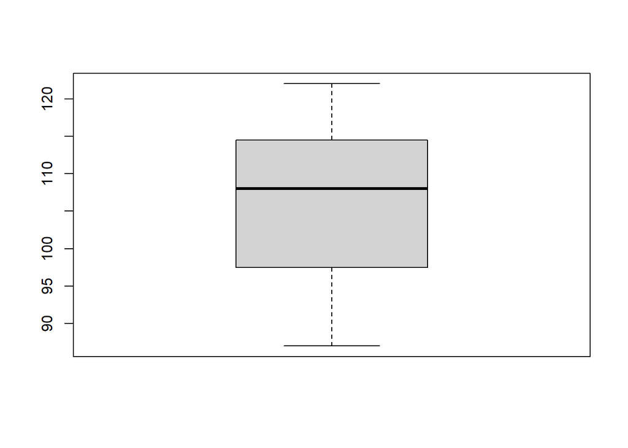

```r
boxplot(crime$mean_education)
```

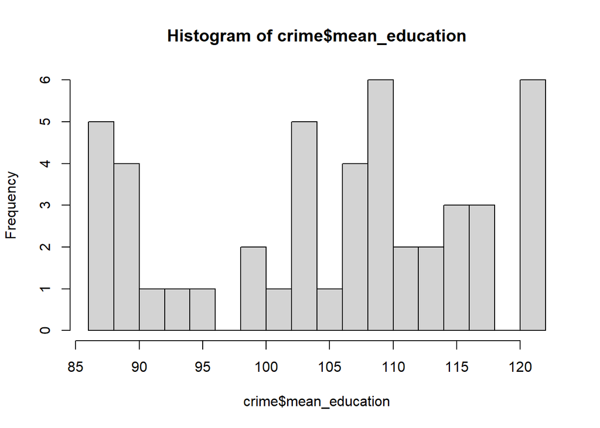

```r
hist(crime$mean_education, breaks = 15)
```

```r
mean(crime$mean_education)
```

```
## [1] 105.6383
```

> This graph can explain why mean_education has the positive relation with the crime rate. From boxplot, most of the people have a middle education level than the average. The very low educated people may not commit crimes but maybe the middle educated do so. This implicates to the positive coefficient value of mean_eduacation variable towards the model.

```r
library(performance)

compare_performance(backward, forward, both1, both2)
```

```
## # Comparison of Model Performance Indices
##
## Model    | Type |    AIC |    BIC |   R2 | R2 (adj.) |   RMSE |  Sigma |   BF |     p
## -------------------------------------------------------------------------------------
## backward |   lm | 639.32 | 657.82 | 0.79 |      0.74 | 175.83 | 195.55 | 1.00 |
## forward  |   lm | 640.17 | 654.97 | 0.77 |      0.73 | 185.14 | 200.69 | 4.16 | 0.127
## both1    |   lm | 639.32 | 657.82 | 0.79 |      0.74 | 175.83 | 195.55 | 1.00 | 0.127
## both2    |   lm | 640.17 | 654.97 | 0.77 |      0.73 | 185.14 | 200.69 | 4.16 | 0.127
```

## Model prediction based on stepwise backward model

> Based on the Adjusted R-Square and RMSE value, the best model is the backward/model 5

```r
crime$pred_crime <- predict(object = crime_model5, newdata = crime)

crime
```

```
##    percent_m is_south mean_education police_exp60 police_exp59
## 1        151        1             91           58           56
## 2        143        0            113          103           95
## 3        142        1             89           45           44
## 4        136        0            121          149          141
## 5        141        0            121          109          101
## 6        121        0            110          118          115
## 7        127        1            111           82           79
## 8        131        1            109          115          109
## 9        157        1             90           65           62
## 10       140        0            118           71           68
## 11       124        0            105          121          116
## 12       134        0            108           75           71
## 13       128        0            113           67           60
## 14       135        0            117           62           61
```

[output cut: 129 more lines]

## Normality Error

> Visualize the histogram of yielded error. - Good model should have the error value that distributed with normal distribution, scattered around mean value.

> Test of Normality Error:
> 1. Visualizing the histogram of error

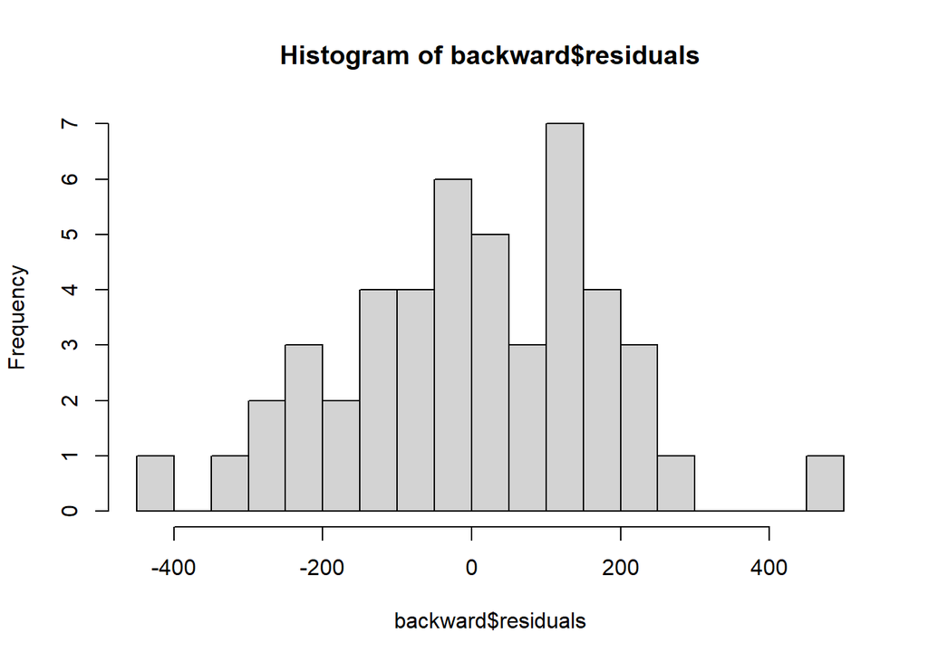

```r
hist(backward$residuals, breaks = 20)
```

> 2. Statistical test using ’shapiro.test()` function

> Shapiro-Wilk hypothesis:
> - H0: error/residual distributed normally
> - H1: error/residual is not distributed normally

```r
shapiro.test(backward$residuals)
```

```
##
##  Shapiro-Wilk normality test
##
## data:  backward$residuals
## W = 0.98511, p-value = 0.8051
```

> Assuming alpha value is 0.05. The p-value is higehr than alpha. Accept H0 : Error is distributed normally.

### Homoscedasticity Test

> Test the variance of error in the model - Good model should have a low variance of error

> Test of Homoscedasticity 1. Visualizing the error value by scatter plot

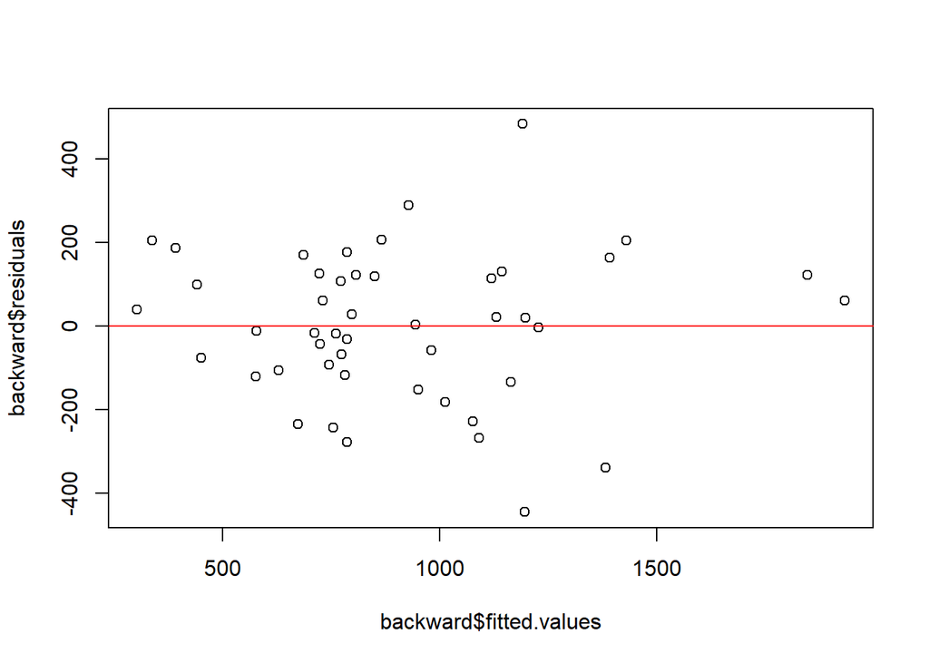

```r
plot(backward$fitted.values, backward$residuals)
abline(h=0, col = "red")
```

> 2. Statistical test using Breusch-Pagan by `bptest()` function from library `lmtest`

> Breusch-Pagan hypothesis :
> - H0: The model is Homoscedasticity
> - H1: The model is Heteroscedasticity

```r
library(lmtest)
bptest(backward)
```

```
##
##  studentized Breusch-Pagan test
##
## data:  backward
## BP = 13.51, df = 8, p-value = 0.09546
```

> Assuming alpha value is 0.05. The p-value is higehr than alpha. Accept H0 : The model is homoscedasticity.

### No-multicolinearity (No correlation between predictor variables)

> Test to examine whether there is correlation between the predictor variables - Good model should not have multicolinearity - The test is undertaken by examine the vif value using `vif()` function from library `car`. - When the VIF value is under 10, the assumption of no-multicolinearity is fulfilled.

```r
library(car)
vif(backward)
```

```
##      percent_m mean_education   police_exp60     m_per1000f   unemploy_m24
##       2.131963       4.189684       2.560496       1.932367       4.360038
##   unemploy_m39     inequality    prob_prison
##       4.508106       3.731074       1.381879
```

> All the predictor variables show the VIF value under 10.